# 第12课 RCS 答案

顶刊研习社

Li Zongzhang

2023-10-29

```r
library(boot)
library(tidyverse)
library(survival)
library(survminer)
library(gt)
library(gtsummary)
```

# 1 习题1

数据：rcssci::sbpdata

1.1 查看rcssci包中sbpdata数据框的帮助文档。

```r
library(rcssci)
data(sbpdata)
head(sbpdata)
```

```
# A tibble: 6 × 5
  gender status   age   sbp  time
   <dbl>  <dbl> <dbl> <dbl> <dbl>
1      1      1    77  101.   177
2      2      1    53  113.   164
3      1      0    70  115.   197
4      2      1    75  128    170
5      2      0    63  121.   182
6      2      0    61  111.   184
```

```r
?rcssci::sbpdata
```

1.2 构建关于status的logistic回归模型，解释变量中有age, sbp和gender, 引入age的rcs项，并考察rcs与logistic回归模型的因变量的非线性关系是否显著。

```r
library(rms)
dd<-datadist(sbpdata)
options(datadist='dd')

logit_rcs <- lrm(status ~ rcs(age, 4) + sbp + gender, sbpdata)
summary(logit_rcs)
```

```
             Effects              Response : status

 Factor      Low    High   Diff.  Effect   S.E.     Lower 0.95 Upper 0.95
 age          57.00  78.00 21.000  1.33950 0.116460  1.11120    1.56770
  Odds Ratio  57.00  78.00 21.000  3.81700       NA  3.03800    4.79580
 sbp         115.33 142.67 27.333  0.23012 0.056895  0.11861    0.34163
  Odds Ratio 115.33 142.67 27.333  1.25870       NA  1.12590    1.40720
 gender        1.00   2.00  1.000 -0.44837 0.083168 -0.61138   -0.28537
  Odds Ratio   1.00   2.00  1.000  0.63867       NA  0.54260    0.75174
```

```r
anova(logit_rcs)
```

```
                Wald Statistics          Response: status

 Factor     Chi-Square d.f. P
 age        460.30     3    <.0001
  Nonlinear  79.64     2    <.0001
 sbp         16.36     1    1e-04
 gender      29.06     1    <.0001
 TOTAL      589.00     5    <.0001
```

1.3 构建关于status的logistic回归模型，解释变量中有age, sbp和gender, 引入age的rcs项，sbp的rcs项，并考察模型中的非线性关系是否显著。

```r
logit_rcs <- lrm(status ~ rcs(age, 4) + rcs(sbp, 4) + gender, sbpdata)
summary(logit_rcs)
```

```
             Effects              Response : status

 Factor      Low    High   Diff.  Effect   S.E.     Lower 0.95 Upper 0.95
 age          57.00  78.00 21.000  1.32550 0.117080  1.09600    1.55500
  Odds Ratio  57.00  78.00 21.000  3.76400       NA  2.99220    4.73490
 sbp         115.33 142.67 27.333  0.37853 0.111070  0.16085    0.59622
  Odds Ratio 115.33 142.67 27.333  1.46010       NA  1.17450    1.81520
 gender        1.00   2.00  1.000 -0.46893 0.083854 -0.63328   -0.30458
  Odds Ratio   1.00   2.00  1.000  0.62567       NA  0.53085    0.73743
```

```r
anova(logit_rcs)
```

```
                Wald Statistics          Response: status

 Factor          Chi-Square d.f. P
 age             455.49     3    <.0001
  Nonlinear       75.47     2    <.0001
 sbp              39.99     3    <.0001
  Nonlinear       24.25     2    <.0001
 gender           31.27     1    <.0001
 TOTAL NONLINEAR 102.87     4    <.0001
 TOTAL           601.07     7    <.0001
```

```r
# age的非线性项显著，sbp的非线性项显著.
```

1.4 用ggplot2绘制出1.3中的模型中age与odds ratio的关系图, sbp与odds ratio的关系图。

```r
# sbp的中位数等于128，gender = reference group
median(sbpdata$sbp)
```

```
[1] 128
```

```r
logit_rcs_predict_OR <- Predict(logit_rcs,
                             age,
                             sbp = 128,
                             np = 100,
                             fun = exp)

median(sbpdata$age)
```

```
[1] 69
```

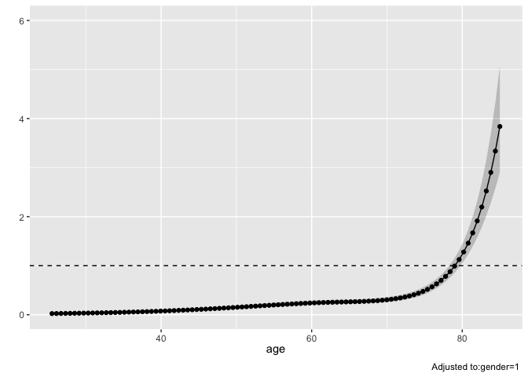

```r
logit_rcs_predict_OR %>%
  ggplot(aes(age, yhat)) +
  geom_point() +
  geom_hline(yintercept = 1, linetype = 2)
```

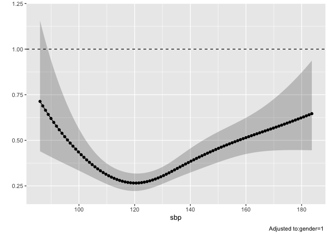

```r
logit_rcs_predict_OR <- Predict(logit_rcs,
                             age = 69,
                             sbp,
                             np = 100,
                             fun = exp)

logit_rcs_predict_OR %>%
  ggplot(aes(sbp, yhat)) +
  geom_point() +
  geom_hline(yintercept = 1, linetype = 2)
```

1.5 用ggplot2绘制出1.3中的模型中, 当sbp分别去其10%，30%，50%，70%，90%时，age与odds ratio的关系图；当age分别去其10%，30%，50%，70%，90%时， sbp与odds ratio的关系图。

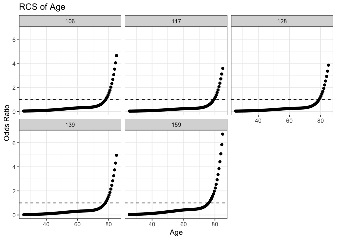

```r
logit_rcs_pred_OR <- Predict(logit_rcs,
                             sbp = round(quantile(sbpdata$sbp, seq(0.1,0.9,0.2))),
                             age,
                             np = 100,
                             fun = exp) %>%
  as.data.frame()


logit_rcs_pred_OR %>%
  ggplot(aes(age, yhat)) +
  geom_point() +
  facet_wrap( ~ sbp) +
  scale_color_manual(values = c("green", "blue")) +
  geom_hline(yintercept = 1, linetype = 2) +
  theme_bw() +
  theme(legend.position = "bottom") +
  labs(title = "RCS of Age",
       x = "Age",
       y = "Odds Ratio")
```

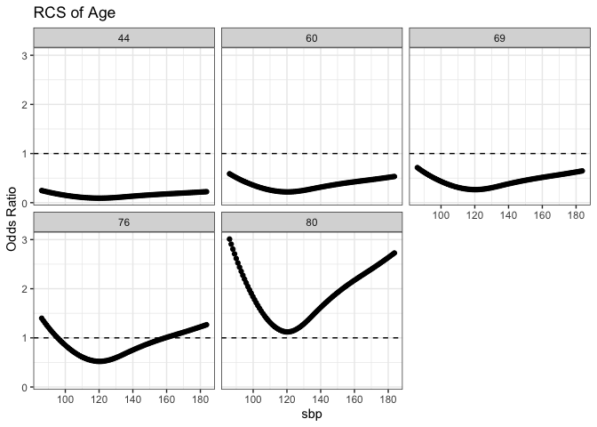

```r
logit_rcs_pred_OR <- Predict(logit_rcs,
                             sbp ,
                             age = round(quantile(sbpdata$age, seq(0.1,0.9,0.2))),
                             np = 100,
                             fun = exp) %>%
  as.data.frame()


logit_rcs_pred_OR %>%
  ggplot(aes(sbp, yhat)) +
  geom_point() +
  facet_wrap( ~ age) +
  geom_hline(yintercept = 1, linetype = 2) +
  theme_bw() +
  theme(legend.position = "bottom") +
  labs(title = "RCS of Age",
       x = "sbp",
       y = "Odds Ratio")
```